# Genotype

Ying Wang

08/03/2021

# 1 Dataset Description

A total of **7880** individuals from **2611** families were genotyped on Illumina Human 1Mv1.

- 4901 males, 2979 females.
- 2571 trios, 36 quads, 1 pentas, 3 hexs.
- 947,233 SNPs were genotyped.
- Coordinates were based on Build36.

# 2 Raw Genotype QC

## 2.1 Sex Check

- 141 PRROBLEM
  - 115 with complete missing chrX genotypes.
  - 26 with chrX-F ranging from 0.20 to 0.62

### 2.1.1 Mismatch summary

| FID | IID | PEDSEX | SNPSEX | STATUS | F |
| --- | --- | --- | --- | --- | --- |
| 100 | 100_4385 | 2 | 0 | PROBLEM | 0.3336 |
| 101 | 101_3086 | 2 | 0 | PROBLEM | 0.2125 |
| 141 | 141_4343 | 2 | 0 | PROBLEM | 0.243 |
| 190 | 190_951 | 2 | 0 | PROBLEM | 0.223 |
| 231 | 231_322 | 2 | 0 | PROBLEM | 0.2696 |
| 693 | 693_2387 | 2 | 0 | PROBLEM | 0.3115 |
| 753 | 753_2229 | 2 | 0 | PROBLEM | 0.235 |
| 911 | 911_111 | 2 | 0 | PROBLEM | 0.2111 |
| 1038 | 1038_4078 | 2 | 0 | PROBLEM | 0.6207 |
| 1120 | 1120_1013 | 2 | 0 | PROBLEM | 0.3258 |

[output cut: 16 more lines]

### 2.1.2 ChrX F distributions

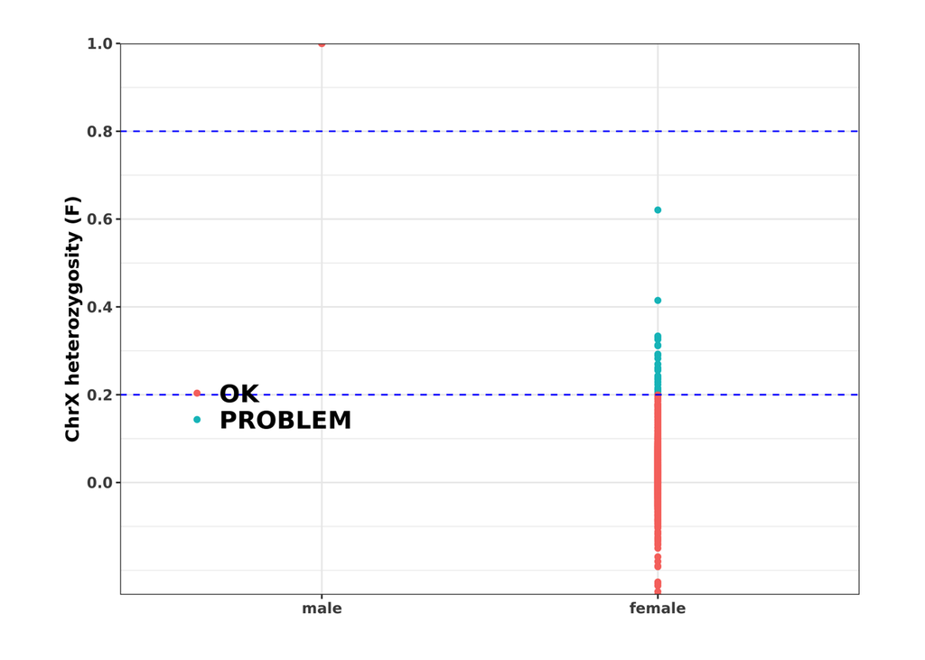

## 2.2 Pariwise IBD estimation

- Relationships (RT): OT (Others), FS (Full Siblings), PO (Parent Offspring)
- family ID 483 has potential issue
  - inbreeding coefficient = 1 between IID:328 (Female) and IID:1491 (Female)
  - MZ? same individual?

### 2.2.1 Estimated pairwise IBD distributions

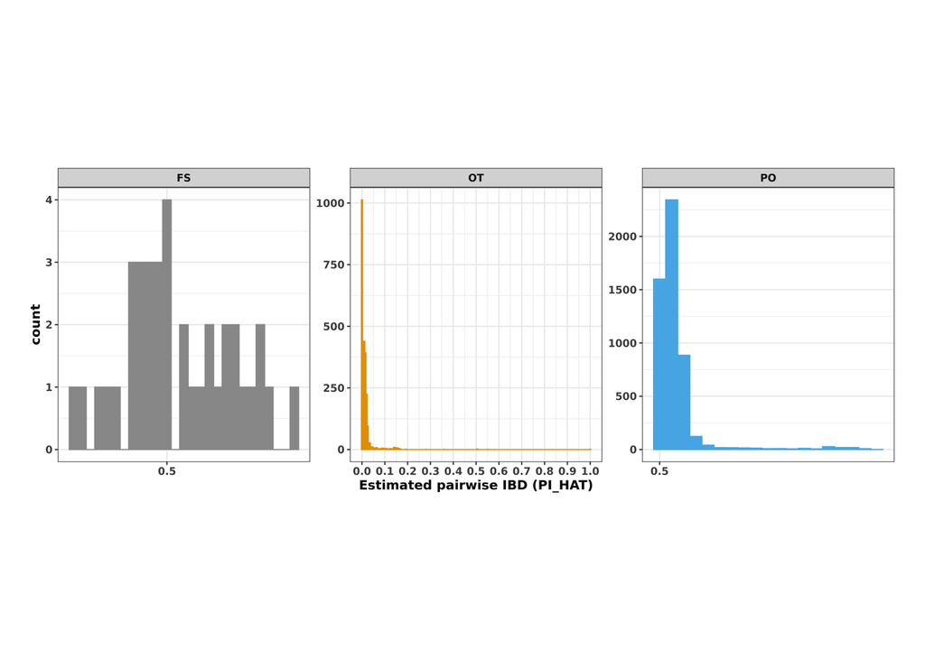

### 2.2.2 Family 483

| FID1 | IID1 | FID2 | IID2 | RT | EZ | Z0 | Z1 | Z2 | PI_HAT | PHE | DST | PPC | RATIO |
| --- | --- | --- | --- | --- | --- | --- | --- | --- | --- | --- | --- | --- | --- |
| 483 | 483_328 | 483 | 483_725 | PO | 0.5 | 0 | 0.9897 | 0.0103 | 0.5052 | -1 | 0.811031 | 1 |  |
| 483 | 483_328 | 483 | 483_993 | OT | 0 | 0.0003 | 0.9905 | 0.0092 | 0.5045 | -1 | 0.810789 | 1 |  |
| 483 | 483_328 | 483 | 483_1491 | OT | 0 | 0 | 0.0001 | 0.9999 | 0.9999 | -1 | 0.999976 | 1 |  |
| 483 | 483_328 | 483 | 483_2783 | OT | 0 | 0.9716 | 0.0172 | 0.0112 | 0.0198 | -1 | 0.711179 | 0.8503 | 2.0789 |
| 483 | 483_328 | 483 | 483_4371 | OT | 0 | 0.9907 | 0.0079 | 0.0014 | 0.0053 | -1 | 0.707333 | 0.1957 | 1.9383 |
| 483 | 483_725 | 483 | 483_993 | OT | 0 | 0.6199 | 0.3681 | 0.012 | 0.1961 | -1 | 0.747542 | 1 | 3.4549 |
| 483 | 483_725 | 483 | 483_1491 | OT | 0 | 0.0003 | 0.9888 | 0.0109 | 0.5053 | -1 | 0.811111 | 1 | 2919 |
| 483 | 483_725 | 483 | 483_2783 | PO | 0.5 | 0 | 0.9898 | 0.0102 | 0.5051 | -1 | 0.810995 | 1 |  |
| 483 | 483_725 | 483 | 483_4371 | OT | 0 | 1 | 0 | 0 | 0 | -1 | 0.709612 | 0.2665 | 1.9549 |
| 483 | 483_993 | 483 | 483_1491 | PO | 0.5 | 0 | 0.9911 | 0.0089 | 0.5044 | -1 | 0.810753 | 1 |  |

[output cut: 5 more lines]

## 2.3 Individual genome-wide heterozygosity

### 2.3.1 Genome-wide heterozygosity VS missing rates

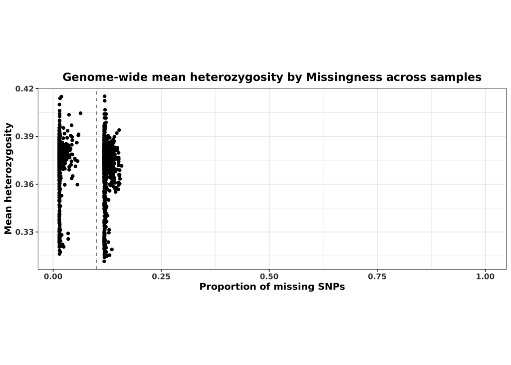

### 2.3.2 Genome-wide F VS missing rates

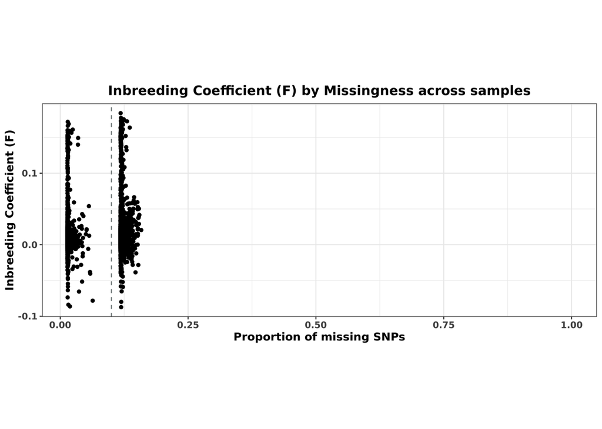

# 3 Imputation

## 3.1 Pre-imputation

The imputation pipeline follows that used for SSC dataset. A total of **7769** individuals and ~784K autosomal, ~22K chrX SNPs were used for further impution.

- filters: -- geno 0.05 --mind 0.2 --maf 0.01 --hwe 1e-6
  - 111 people removed due to missing genotype data (–mind).
  - Total genotyping rate in remaining samples is 0.914029.
  - 124565 variants removed due to missing genotype data (–geno).
  - 15633 variants removed due to Hardy-Weinberg exact test.

Note that a liberal threshold 0.2 was used for individual genotype missing rates (–mind) for AGP data here since, a large number of individuals with imiss > 0.1. 111 people with imiss ranging from 0.7 to 1.

## 3.2 After Imputation

### 3.2.1 Frequency distribution

### 3.2.2 PCA